# Ecological niche models of plant species exploited by Epipalaeolithic foragers in the *Badia* (c. 14500 BP)

## Dependencies

```r
library("tidyverse")
library("magrittr")
library("sf")
library("raster")
library("broom")
library("dismo")
library("rnaturalearth")
library("gt")
library("BadiaPaleoFloraENM")
```

## Introduction

First, we define our regions of interest:

```r
sw_asia <- extent(c(30, 50, 25, 40))
s_levant <- extent(c(34, 39, 29, 34))
palestine <- ne_countries(scale = 10, country = c("Israel", "Palestine"),
             returnclass = "sf") %>% st_union() %>% st_sf()

land <- read_sf("data/raw_data/ne/ne_10m_land.shp")[,"featurecla"] %>%
  st_crop(sw_asia)
rivers <- read_sf("data/raw_data/ne/ne_10m_rivers_lake_centerlines_scale_rank.shp") %>%
  st_crop(s_levant)
water <- rbind(read_sf("data/raw_data/ne/ne_10m_ocean.shp")[,"featurecla"],
               read_sf("data/raw_data/ne/ne_10m_lakes.shp")[,"featurecla"]) %>%
  st_crop(sw_asia)
```

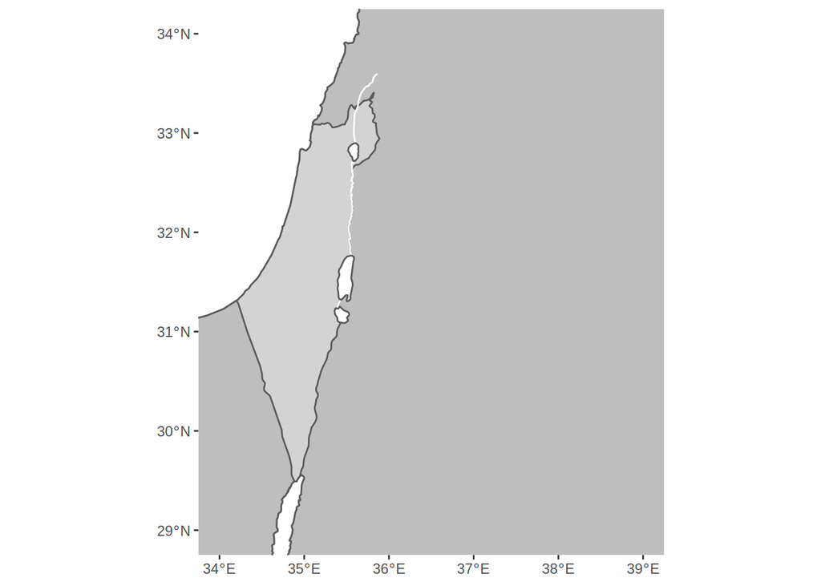

## Occurrence data

```r
# Download or read data from GBIF
gbif_path <- here::here("analysis/data/raw_data/gbif")
occ <- bind_rows(
  fetch_gbif("Hordeum", "spontaneum*", ext = sw_asia, gbif_path),
  fetch_gbif("Bolboschoenus", "glaucus*", ext = sw_asia, gbif_path),
  fetch_gbif("Bolboschoenus", "maritimus*", ext = sw_asia, gbif_path),
  fetch_gbif("Scirpus", "maritimus*", ext = sw_asia, gbif_path),
  fetch_gbif("Triticum", "urartu*", ext = sw_asia, gbif_path),
  fetch_gbif("Triticum", "dicoccoides*", ext = sw_asia, gbif_path),
  fetch_gbif("Stipa", "*", ext = sw_asia, gbif_path),
  fetch_gbif("Zilla", "spinosa*", ext = sw_asia, gbif_path),
  fetch_gbif("Vitex", "*", ext = sw_asia, gbif_path),
  fetch_gbif("Fraxinus", "*", ext = sw_asia, gbif_path)
)

# Code taxonomic groups for analysis
occ %>%
  mutate(taxon = case_when(genus == "Hordeum" ~ "Hordeum spontaneum",
                           genus == "Bolboschoenus" ~ "Bolboschoenus sp. (=Scirpus maritimus)",
                           species == "Triticum urartu" ~ "Triticum urartu",
                           species == "Triticum dicoccoides" ~ "Triticum dicoccoides",
                           genus == "Stipa" ~ "Stipa sp.",
                           genus == "Zilla" ~ "Zilla spinosa",
                           genus == "Vitex" ~ "Vitex sp.",
                           genus == "Fraxinus" ~ "Fraxinus sp.")) %T>%
  {if(any(is.na(.$taxon))) stop("Taxon contains missing values!")} ->
  occ


# Remove duplicate records within analytic groups
occ %>%
  group_by(taxon) %>%
  distinct(lon, lat, .keep_all = TRUE) %>%
  ungroup() ->
  occ

# Convert to sf
occ %>%
  st_as_sf(coords = c("lon", "lat"), crs = 4326, remove = FALSE) ->
  occ
```

It’s interesting to map the current distribution of these plants.

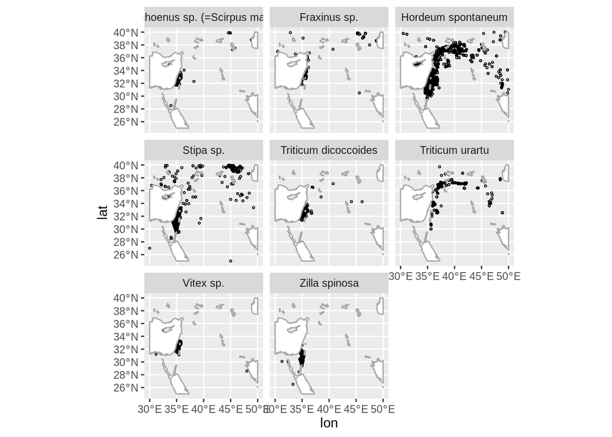

## Pseudo-absences

Occurrence data only tells us where a species is present; there is no definitive information on where the species is *not* found. We therefore need to generate random background points or “pseudo-absences” to feed to the model. There are several ways to do this. We follow the advice of Barbet-Massin et al. (2012) for regression-based species distribution models and simply use a large (~10000) random sample of points.

```r
occ <- as_tibble(occ)
occ$occurrence <- TRUE
for(taxon in unique(occ$taxon)) {
  occ <- bind_rows(occ, generate_psabsences(palestine, taxon = taxon,
                                            occurrence = FALSE, N = 10000))
}
occ <- sf::st_as_sf(occ, crs = 4326)
rm(taxon)
```

## Environmental data

### Bioclimatic variables

To construct the model, we’ll use a standard set of “bioclimatic” predicator variables. These sixteen variables are derived from monthly precipitation and temperate data:

| biovar | definition | formula |
| --- | --- | --- |
| bio1 | Mean annual temperature |  |
| bio2 | Mean diurnal range |  |
| bio3 | Isothermality | (bio2 / bio7) * 100 |
| bio4 | Temperature seasonality | sd(temp) * 100 |
| bio5 | Maximum temperature of warmest month |  |
| bio6 | Minimum temperature of coldest month |  |
| bio7 | Annual temperature range | bio5 - bio6 |
| bio8 | Mean temperature of wettest quarter |  |
| bio9 | Mean temperature of driest quarter |  |
| bio10 | Mean temperature of warmest quarter |  |
| bio11 | Mean temperature of coldest quarter |  |
| bio12 | Total annual precipitation |  |
| bio13 | Precipitation of wettest month |  |
| bio14 | Precipitation of driest month |  |
| bio15 | Precipitation seasonality |  |
| bio16 | Precipitation of wettest quarter |  |

Here the climate data is from WorldClim 1.4 (http://www.worldclim.org), a global dataset compiled from weather station records from the period 1960–1990. WorldClim has been widely used in ecological niche modelling. Other global climate datasets (e.g. CHELSA, MERRAClim) and a newer version of WorldClim are now available, so it may be a good idea to investigate using these instead. The WorldClim data is large so again it is cached in the package’s `derived_data` directory.

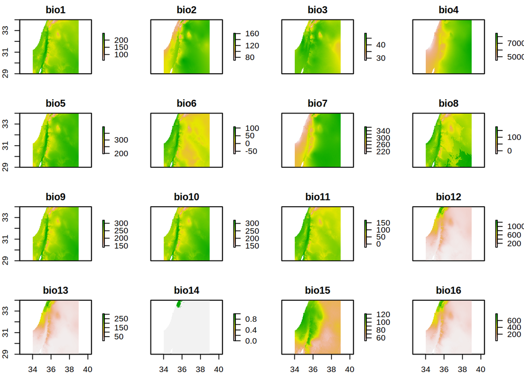

### Soil variables

Velazco et al. (2017) have shown that edaphic data, recently available on a global scale, is usefully combined with bioclimatic data in modelling plant niches.

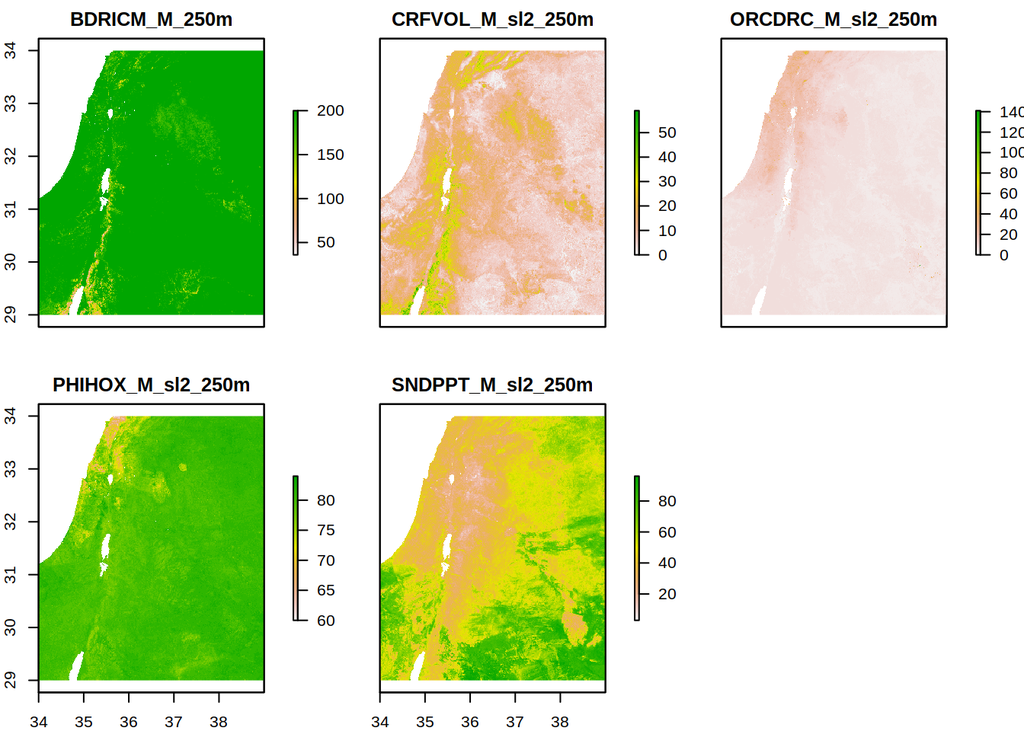

```r
soilgrids <- raster::stack(list.files("data/raw_data/soilgrids", ".*tif", full.names = TRUE))
plot(soilgrids)
```

### Terrain

There are also relevent aspects of the terrain that can be easily derived from a digital elevation model. We’ll use NASA-JPL’s SRTM v3 1 arc-second resolution DEM.

### Selection of predictor variables

We reviewed existing floras to identify specific variables from these datasets that are relevant to the niche of our target taxa. The results are summarised below.

| Factor | Notes | Reference |
| --- | --- | --- |
| Triticum sp. |  |  |
| Precipitation | Adapted to dry conditions, at least 400 mm per annum for T. dicoccoides, or 300–350 mm for T. urartu and T. boeoticum. | NA |
| Soil type | T. urartu and T. boeoticum prefer basalt calcareous soils. | NA |
| Soil acidity | Found in acidic soils (limited distribution) | NA |
| Terrain | 100 m asl to 1600–1650 m asl. T. dicoccoides grows on mountain slopes. | NA |
| Hordeum spontaneum |  |  |
| Precipitation | Adapted to dry conditions, at least 200–250 mm rainfall per annum. | NA |
| Temperature | Not tolerant of cool conditions. | NA |
| Soil type | Tolerant of poor calcareous soils. | NA |
| Terrain | Grows on rocky limestone slopes, marly banks, and waste places, between 30 and 1650 m asl. | NA |
| Stipa sp. |  |  |
| Terrain | Grows on limestone mountain slopes between 400 and 2500 m asl. | NA |
| Vitex sp. |  |  |
| Water | Grows close to water resources, banks of streams and dry wadis | NA |
| Terrain | No higher than 750 m asl, mostly on sandy groumd, alluvial soils, rocky areas, dry river beds. | NA |
| Zilla spinosa |  |  |
| Soil type | Sandy deserts, dry soils, stony ground. | NA |
| Bolboschoenus glaucus |  |  |
| Water | A wetland plant, it grows in the shores of the lakes, often underwater. The subspecies maritimus (sea club-rush) grows in freshwater or saline marshes with Typha, Juncus and Phragmites, stagnant swamp… | NA |
| Salinity | Some club rush like sea-club-rush can tolerate high salinity. | NA |
| Terrain | Grows anywhere between 0 and 2000 m asl. | NA |
| Fraxinus sp. |  |  |
| Water | Along with rivers and streams. 400-1900 small, by streams often in comparatively dry and rocky places | NA |
| Terrain | Mostly dryish, rocky places, in macchie, deciduous scrub or forest, Pinus brutia or P. nigra forests, or mixed forest, 650–1700 m asl. | NA |

Based on these results, we made the following initial selection of predictor variables to build the models.

| variable | units | source | code |
| --- | --- | --- | --- |
| Climate |  |  |  |
| Minimum temperature of coldest month | °C ×10 | WorldClim 1.4 | bio6 |
| Total annual precipitation | mm | WorldClim 1.4 | bio12 |
| Precipitation of wettest month | mm | WorldClim 1.4 | bio13 |
| Precipitation of driest month | mm | WorldClim 1.4 | bio14 |
| Precipitation seasonality | σ/μ | WorldClim 1.4 | bio15 |
| Soil |  |  |  |
| Organic carbon content | g per kg fine earth | SoilGrids250m | ORCDRC_M_sl2_250m |
| Coarse fragment content | % volume | SoilGrids250m | CRFVOL_M_sl2_250m |
| Sand content | % mass | SoilGrids250m | SNDPPT_M_sl2_250m |
| Acidity | pH ×10 in H2O | SoilGrids250m | PHIHOX_M_sl2_250m |
| Depth to bedrock | cm (up to 200 cm) | SoilGrids250m | BDRICM_M_250m |

One aspect that we cannot easily incorporate into the models is the interaction between these taxa and other plant and animal species: cereal grasses grow best when they have no competition from perennial plants, *Fraxinus* often grows in scrub or forest, and so on.

We also lack data for soil salinity so far.

### Combining predictor variables

```r
pred$raster <- lapply(pred$raster, raster::resample, y = bioclim, method = "ngb")
```

## Model construction

We will model the ecological niche of each species using a generalised linear regression.

First we extract the values of the predictor variables at each occurrence and pseudo-absence location:

```r
# TODO: refactor to use pred
bioclim %>%
  raster::extract(as_Spatial(occ)) %>%
  {cbind(occ, .)} %>%
  st_as_sf(crs = st_crs(occ)) ->
  occ

soilgrids %>%
  raster::extract(as_Spatial(occ)) %>%
  {cbind(occ, .)} %>%
  st_as_sf(crs = st_crs(occ)) ->
  occ
```

### Species response curves

We can use species response curves to visualise the distribution of known occurrences in relation to these environmental gradients. This will also help us parameterise the ecological niche models.

```r
# Summarise occurrences on a grid
palestine %>%
  as_Spatial() %>%
  raster::rasterize(bioclim) ->
  palestine_raster

occ %>%
  filter(occurrence == TRUE) %>%
  group_by(taxon) %>%
  do(occ_grid = raster_burn(., palestine_raster)) ->
  occ_grids

# Fit poly(1:3) to each taxon/predictor combination
expand.grid(taxon = unique(occ$taxon),
            predictor = pred$code,
            polyn = 1:3) %>%
  group_by(taxon, predictor, polyn) %>%
  do(
    # TODO: It works but I hate it.
    fit = model_response(unlist(occ_grids[occ_grids$taxon == .$taxon, "occ_grid"])[[1]],
                         unlist(pred[pred$code == .$predictor, "raster"])[[1]],
                         .$polyn)
  ) %>%
  glance(fit) ->
  response_glm
```

The optimal model is the one with the lowest AIC.

```r
response_glm %>%
  group_by(taxon, predictor) %>%
  mutate(optimum = polyn == which.min(AIC)) ->
  response_glm

# TODO
# Re-fit and plot optimal
# model_response(occ_grids$occ_grid[[1]], pred$raster[[1]], 2) %>% predict(data.frame(pred = -72:109, type = "response")) %>% plot()
# Need to dplyrise this – see broom::augment()
# response_glm %>%
#   filter(optimum == TRUE) %>%
#   slice(1:3) %>%
#   do(
#     fit = model_response(unlist(occ_grids[occ_grids$taxon == .$taxon, "occ_grid"])[[1]],
#                          unlist(pred[pred$code == .$predictor,"raster"])[[1]],
#                          .$polyn)
#   )
```

### Model fitting

Now we can fit regression models combining all the predictor variables.

```r
# TODO: use optimal polynomial order
occ %>%
  group_by(taxon) %>%
  remove_missing(vars = c("bio1", "bio2", "bio3", "bio4", "bio5", "bio6",
                          "bio7", "bio8", "bio9", "bio10", "bio11", "bio12",
                          "bio13", "bio14", "bio15", "bio16", "bio17", "bio18",
                          "bio19", "BDRICM_M_250m", "CRFVOL_M_sl2_250m",
                          "ORCDRC_M_sl2_250m", "PHIHOX_M_sl2_250m",
                          "SNDPPT_M_sl2_250m")) %>%
  do(model = glm(occurrence ~
                   poly(bio6, 2) +
                   poly(bio12, 2) +
                   poly(bio13, 2) +
                   # poly(bio14, 2) +
                   poly(bio15, 2) +
                   poly(BDRICM_M_250m, 2) +
                   poly(CRFVOL_M_sl2_250m, 2) +
                   poly(ORCDRC_M_sl2_250m, 2) +
                   poly(PHIHOX_M_sl2_250m, 2) +
                   poly(SNDPPT_M_sl2_250m, 2),
                 data = .)) ->
  models
```

## Predicting occurrences

### Current conditions

We can now use the fitted models to predict the occurrence of the different taxa according to the predictor variables. Initially, we do this based on current conditions. This allows us to extrapolate from regions with good occurrence data (i.e. Israel/Palestine) to those without. It also hints at what the distribution of the plant might be under “ideal conditions”, without agriculture, grazing, etc.

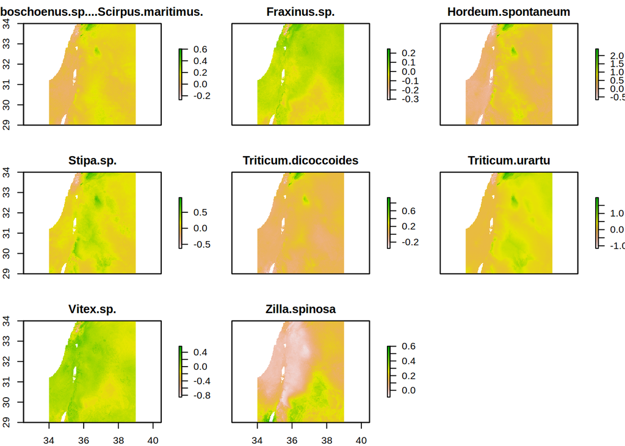

```r
models %>%
  do(taxon = .$taxon,
     model = .$model,
     pred_current = raster::predict(object = raster::stack(pred$raster),
                                    model = .$model)) ->
  models
```

### Binning

```r
raster::stack(models$pred_current) %>%
  set_names(paste0("pred_current_", models$taxon)) %>%
  raster::extract(as_Spatial(occ)) %>%
  {cbind(occ, .)} %>%
  st_as_sf(crs = st_crs(occ)) ->
  occ2
```